# StockResearch

Gabriel Foix

2021-02-26

Buy Quality at the a good momentum and get rid of the fishy stocks on time. That's all.

### Define candidates

Download all info needed applying the following filters:

### Factor 1: Quality

1. Healthy debts: A company shoud generate cash in order to repay its debt. The **Free Cash Flow to Debt** ratio is a good indicator of how quick a company pays back its debt. The lower this ratio the better.

FCF2D = $\frac{Debt}{Free Cash Flow}$

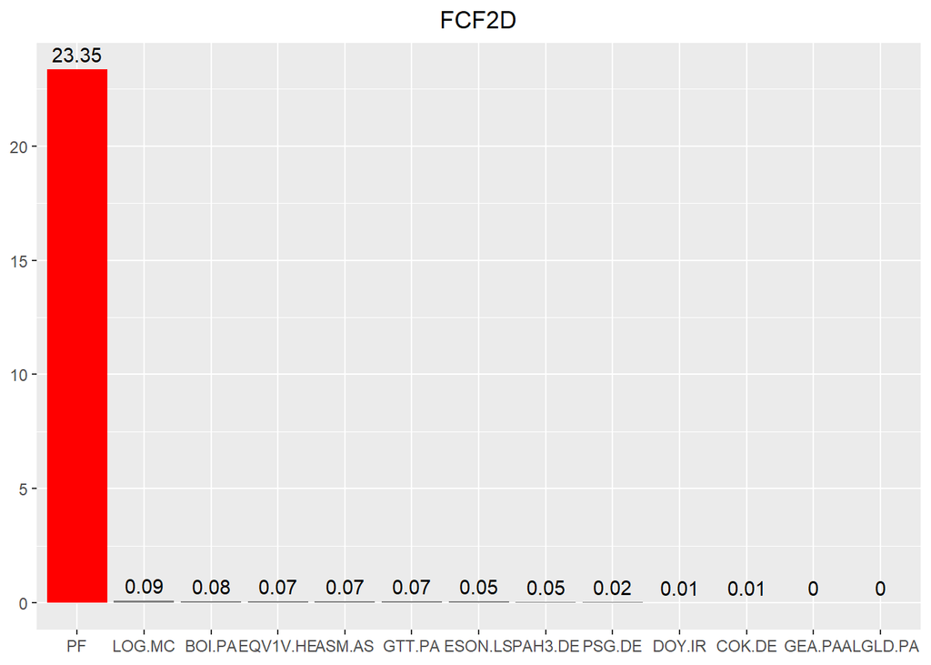

2. Profitability: ROA

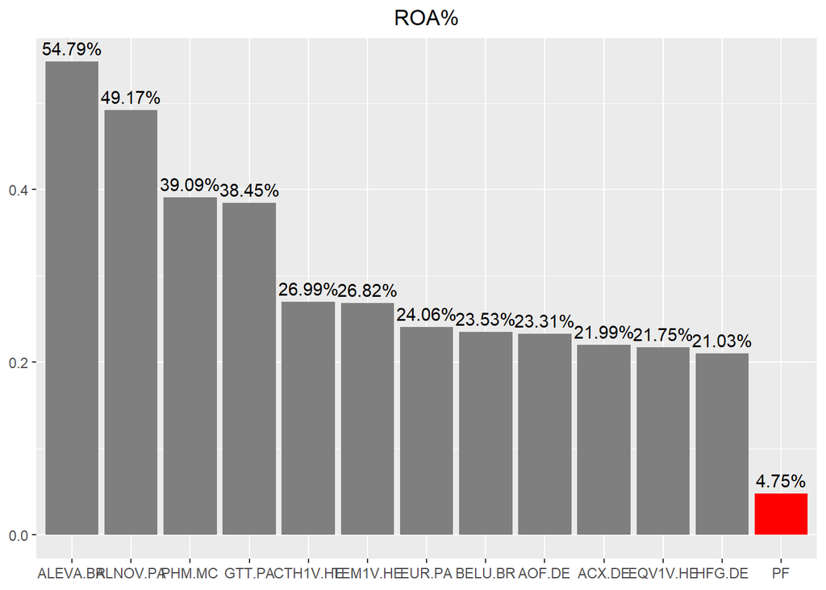

3. High Margin: We look for companies that generate free cash flow compare to its price. The **Free Cash Flow to Entreprise Value** ratio tells us how many years of cash flow would be needed to the return the 100% of the investment. Again, the lower, the better. Values bellow 1 would mean "free lunch".

FCF2EV = $\frac{EV}{Free Cash Flow}$

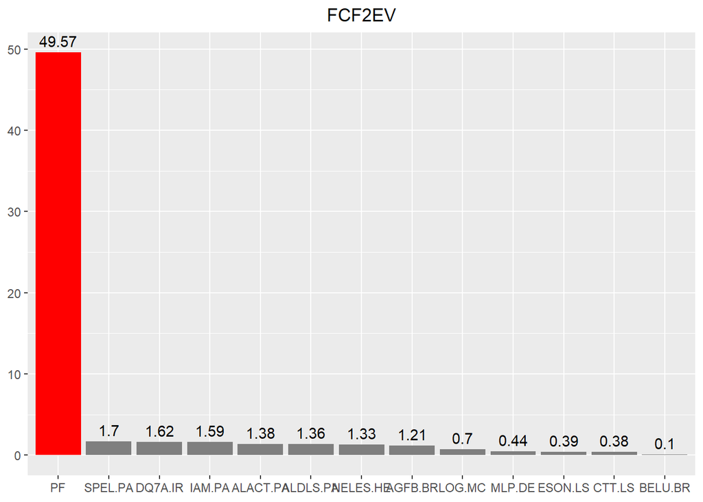

#### Download Historical Data

Download only stocks not filtered previously

### Value touch

Filter out stocks with PER > 40

Report Candidates

Filter Summary

| Filter | NStocks |
| --- | --- |
| Initial | 1577 |
| ROA | 863 |
| FCF | 755 |
| Hist1Y | 749 |
| PER | 477 |

### Factor 2: Momentum

Don't hold onto a stock simply because it is high quality. So called quality stocks have cycles too. Stan Weinstein (page 177)

Generic Intermediate-Term Momentum Based on Gray-Vogel (page 80)

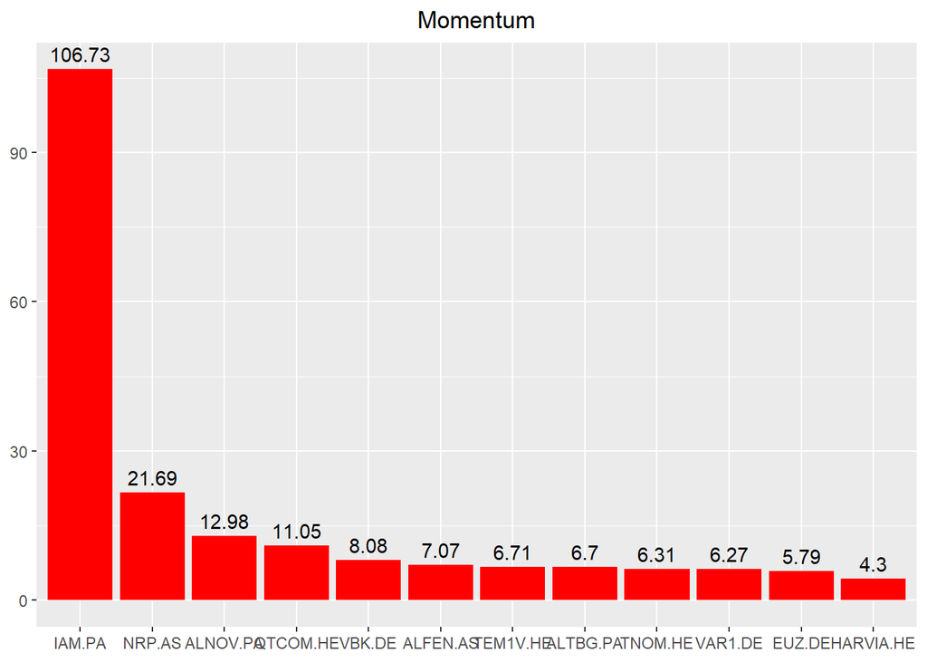

### Factor 3: Timing Signal

Sell Signal - Pr < 1% SMA 30 weeks and slope negative (< -0.2)  
Buy Signal - 109% * SMA30 < Pr > SMA 30 and slope positive (> 0.2)  
Hold Signal - Neither Buy nor Sell

#### Calc Market Cap

Using free float shares

### Summary

Summary

| Ticker | Signal | Quality | Momentum | Final_rank | PER | MCap |
| --- | --- | --- | --- | --- | --- | --- |
| PAY.BR | BUY | 825.0 | 704 | 821.0 | 15.5069586 | 4.661618e+07 |
| ALDNX.PA | HOLD | 818.0 | 707 | 818.0 | 14.3906023 | NA |
| DIGIA.HE | HOLD | 777.5 | 719 | 814.0 | 19.0769232 | 1.129997e+08 |
| ALNOV.PA | BUY | 727.5 | 747 | 810.0 | 13.6577187 | 5.329694e+08 |
| BELU.BR | BUY | 848.0 | 617 | 806.5 | 1.9333334 | NA |
| ALMIC.PA | HOLD | 769.0 | 694 | 804.0 | 36.9999995 | 2.423002e+07 |
| SAA1V.HE | BUY | 820.0 | 642 | 803.0 | 9.0596029 | 5.835467e+08 |
| ALREW.PA | HOLD | 812.0 | 634 | 799.0 | 6.8980479 | 1.420733e+08 |
| UNIAV.HE | HOLD | 754.0 | 691 | 796.0 | 19.5384612 | NA |
| EQV1V.HE | HOLD | 772.0 | 645 | 788.0 | 29.1666667 | 1.390050e+08 |
| ORDI.AS | HOLD | 800.0 | 611 | 785.0 | 13.8493721 | 2.577485e+08 |
| ALPDX.PA | BUY | 789.0 | 621 | 784.0 | 13.2051284 | NA |
| ASM.AS | HOLD | 678.0 | 725 | 782.0 | 35.5089735 | 1.008205e+10 |
| ALVU.PA | HOLD | 787.0 | 615 | 781.0 | 30.4435492 | NA |
| ALNSE.PA | HOLD | 806.0 | 592 | 779.0 | 10.7187108 | NA |
| ALFOC.PA | HOLD | 838.0 | 554 | 777.5 | 26.6609874 | NA |
| TOKMAN.HE | HOLD | 694.5 | 695 | 775.0 | 14.8760331 | 4.624909e+08 |
| ORNBV.HE | HOLD | 770.0 | 612 | 774.0 | 21.7756418 | 4.274532e+09 |
| ROVIO.HE | HOLD | 837.0 | 537 | 770.0 | 14.6009385 | 3.777078e+08 |
| HOLCO.AS | HOLD | 834.0 | 539 | 769.0 | 12.5395268 | 3.527326e+07 |
| VETO.PA | HOLD | 761.0 | 606 | 768.0 | 35.9073359 | 3.608281e+08 |
| GTT.PA | SELL | 763.5 | 602 | 766.0 | 13.0337076 | 1.523125e+09 |
| UPONOR.HE | BUY | 803.0 | 560 | 765.0 | 14.3471079 | 7.431032e+08 |
| ETTE.HE | HOLD | 682.0 | 679 | 762.5 | 21.6666664 | 6.339216e+07 |
| VBK.DE | HOLD | 609.0 | 745 | 760.5 | 25.4023000 | 1.907267e+08 |
| ZENT.BR | HOLD | 782.0 | 572 | 760.5 | 10.4331624 | 2.964295e+07 |
| SPEL.PA | HOLD | 721.0 | 628 | 759.0 | 4.3244949 | 1.705939e+07 |
| ALTXC.PA | HOLD | 706.0 | 638 | 756.0 | 15.1253913 | 2.191882e+06 |
| KESKOB.HE | BUY | 674.0 | 668 | 755.0 | 19.3027531 | 5.635157e+09 |
| KESKOA.HE | BUY | 677.0 | 661 | 754.0 | 18.8532103 | 5.503920e+09 |

[output cut: 447 more lines]

Save output in template